# Class4-missing data

GANYU LIU

2025-09-18

## Helpful information

BRFSS codebook: https://www.cdc.gov/brfss/annual_data/2021/pdf/codebook21_llcp-v2-508.pdf We will use the following variables in this analysis:

MEDCOST1 (1=Yes, 2=No, 7=Don’t know/Not sure, 9=Refused, Blank = not asked or missing) MARITAL (1=Married, 2=Divorced, 3=Widowed, 4=Separated, 5=Never married, 6=a member of an unmarried couple, 9=refused, Blank = not asked or missing)

EMPLOY1** (1=Employed for wages, 2=Self-employed, 3=Out of work for 1 year or more, 4=Out of work for <1 year, 5=A homemaker, 6=A student, 7=Retired, 8=Unable to work, 9=Refused, Blank = not asked or missing)

_SEX (1 = Male, 2=Female)

_EDUCAG (1=Did not graduate high school, 2=Graduated high school, 3=Attended college or technical school, 4=Graduated from college or technical school, 9=Don’t know/Not sure/Missing)

_IMPRACE (1=White, Non-Hispanic , 2=Black, Non-Hispanic, 3=Asian, Non-Hispanic, 4=American Indian/Alaskan Native, Non-Hispanic, 5=Hispanic, 6=Other race, Hispanic)

_AGE80 (18-99) _INCOMG1 (1=<15000, 2=15000-<25000, 3=25000-<35000, 4=35000-<50000, 5=50000-<100000, 6=100000-<200000, 7=200000 or more, 9=Don’t know/Not sure/Missing)

_BMI5 (1-9999, has 2 implied decimal places, calculated WTKG3/(HTM4*HTM4), Blank= Don’t know/Refused/Missing)

# Hypothetical question we are asking: Is income associated with BMI?

## 1. Install packages and open libraries needed for importing data, managing data, and for imputations (code given).

```r
pacman::p_load(haven, tidyverse, naniar, VIM, mice, lattice, table1)
```

## 2. Import the first 10000 rows of LLCP2021.XPT (we are only importing 10K rows so everything is faster). Hints: the BRFSS file name has a space after the .XPT; use the read_xpt function (haven package); using help, look-up the argument for importing a set number of rows (code given).

```r
BRFSS2021 <-
  read_xpt("LLCP2021.XPT ", n_max=10000)
```

## 3. Select the following variables (“MEDCOST1”, “MARITAL”, “EMPLOY1”, “_SEX”, “_EDUCAG”, “_IMPRACE”, “_AGE80”, “_EDUCAG”, “_INCOMG1”, “_BMI5”) to create a smaller dataframe for missing data imputation. Rename variables (code given).

```r
# select variables of interest
df<-BRFSS2021 %>%
  select("MEDCOST1", "MARITAL", "EMPLOY1", "_SEX", "_EDUCAG",  "_IMPRACE", "_AGE80",  "_INCOMG1", "_BMI5")

# rename variables
names(df) <- c("medical_cost", "marital", "employed", "sex", "education", "race", "age", "income", "bmi")
```

## 4. Replace 7 and 9’s as appropriate with NAs (see codebook). Conduct data management for variables (code given).

```r
df <- replace_with_na(df, replace = list(
                               medical_cost = c(7,9),
                               marital = c(9),
                               employed = c(9),
                               sex = c(7,9),
                               education = c(9),
                               race = c(7,9),
                               income = c(9)))

df$medical_cost <- factor(df$medical_cost, levels = c(1,2), labels = c("Yes", "No"))
df$marital <- factor(df$marital, levels = c(1:6), labels = c("Married", "Divorced", "Widowed", "Separated", "Never married", "A member of an unmarried couple"))
df$employed <- factor(df$employed, levels = c(1:8), labels = c("Employed for wages", "Self-employed","Out of work for 1 year or more","Out of work for < 1 year", "A homemaker","A student", "Retired", "Unable to work"))
df$sex <- factor(df$sex, levels = c(1:2), labels = c("Male", "Female"))
df$education <- factor(df$education, levels = c(1:4), labels = c("Did not graduate High School", "Graduated High School","Attended College or Technical School","Graduated from College or Technical School"))
df$race <- factor(df$race, levels = c(1:6), labels = c("White, Non-Hispanic","Black, Non-Hispanic","Asian, Non-Hispanic","American Indian/Alaskan Native, Non-Hispanic","Hispanic","Other race, Non-Hispanic"))
df$income <- factor(df$income, levels = c(1:7), labels =  c("Less than $15,000", "$15,000 to < $25,000", "$25,000 to < $35,000", "$35,000 to < $50,000", "$50,000 to < $100,000", "$100,000 to < $200,000", "$200,000 or more"))

table(df$medical_cost, useNA = "always")
```

```
##
##  Yes   No <NA>
##  831 9127   42
```

```r
table(df$marital, useNA = "always")
```

```
##
##                         Married                        Divorced
##                            5174                            1261
##                         Widowed                       Separated
##                            1093                             238
##                   Never married A member of an unmarried couple
##                            1735                             386
##                            <NA>
##                             113
```

```r
table(df$sex, useNA = "always")
```

```
##
##   Male Female   <NA>
##   4588   5412      0
```

```r
table(df$employed, useNA = "always")
```

```
##
##             Employed for wages                  Self-employed
##                           4105                            859
## Out of work for 1 year or more       Out of work for < 1 year
##                            286                            271
##                    A homemaker                      A student
##                            420                            166
##                        Retired                 Unable to work
##                           3009                            727
##                           <NA>
##                            157
```

```r
table(df$education, useNA = "always")
```

```
##
##               Did not graduate High School
##                                        590
##                      Graduated High School
##                                       2638
##       Attended College or Technical School
##                                       2906
## Graduated from College or Technical School
##                                       3814
##                                       <NA>
##                                         52
```

```r
table(df$race, useNA = "always")
```

```
##
##                          White, Non-Hispanic
##                                         7075
##                          Black, Non-Hispanic
##                                         1272
##                          Asian, Non-Hispanic
##                                          158
## American Indian/Alaskan Native, Non-Hispanic
##                                          687
##                                     Hispanic
##                                          266
##                     Other race, Non-Hispanic
##                                          542
##                                         <NA>
##                                            0
```

```r
table(df$income,  useNA = "always")
```

```
##
##      Less than $15,000   $15,000 to < $25,000   $25,000 to < $35,000
##                    540                    815                    946
##   $35,000 to < $50,000  $50,000 to < $100,000 $100,000 to < $200,000
##                   1048                   2566                   1599
##       $200,000 or more                   <NA>
##                    357                   2129
```

## 5. Understanding the data

### a. Get a summary of each variable in the dataframe to determine how much missing data there is for each variable (code given).

```r
summary(df)
```

```
##  medical_cost                            marital                   employed
##  Yes : 831    Married                        :5174   Employed for wages:4105
##  No  :9127    Divorced                       :1261   Retired           :3009
##  NA's:  42    Widowed                        :1093   Self-employed     : 859
##               Separated                      : 238   Unable to work    : 727
##               Never married                  :1735   A homemaker       : 420
##               A member of an unmarried couple: 386   (Other)           : 723
##               NA's                           : 113   NA's              : 157
##      sex                                            education
##  Male  :4588   Did not graduate High School              : 590
##  Female:5412   Graduated High School                     :2638
##                Attended College or Technical School      :2906
##                Graduated from College or Technical School:3814
##                NA's                                      :  52
##
##
##                                            race           age
##  White, Non-Hispanic                         :7075   Min.   :18.00
##  Black, Non-Hispanic                         :1272   1st Qu.:41.00
##  Asian, Non-Hispanic                         : 158   Median :58.00
##  American Indian/Alaskan Native, Non-Hispanic: 687   Mean   :54.67
##  Hispanic                                    : 266   3rd Qu.:69.00
##  Other race, Non-Hispanic                    : 542   Max.   :80.00
##
##                     income          bmi
##  $50,000 to < $100,000 :2566   Min.   :1331
##  $100,000 to < $200,000:1599   1st Qu.:2428
##  $35,000 to < $50,000  :1048   Median :2778
##  $25,000 to < $35,000  : 946   Mean   :2885
##  $15,000 to < $25,000  : 815   3rd Qu.:3212
##  (Other)               : 897   Max.   :8910
##  NA's                  :2129   NA's   :813
```

### b. Create a variable for missing BMI (bmi_miss) our outcome of interest (code given).

```r
df$bmi_miss <- ifelse(is.na(df$bmi), 1, 0)
# check new variable
table(df$bmi_miss)
```

```
##
##    0    1
## 9187  813
```

```r
# 0: 9187 1:813 (813 are missing)
```

### c. Use the table1 function (code provided below to examine differences between those with missing data and those without missing data) (code given). Comment on what differences you see.

```r
# Run a table 1 to look at differences on other variables between those with missing and non-missing BMI
table1(~medical_cost + age + employed + sex + education + race + income|bmi_miss, df)
```

|  | 0 (N=9187) | 1 (N=813) | Overall (N=10000) |
| --- | --- | --- | --- |
| medical_cost |  |  |  |
| Yes | 763 (8.3%) | 68 (8.4%) | 831 (8.3%) |
| No | 8394 (91.4%) | 733 (90.2%) | 9127 (91.3%) |
| Missing | 30 (0.3%) | 12 (1.5%) | 42 (0.4%) |
| IMPUTED AGE VALUE COLLAPSED ABOVE 80 |  |  |  |
| Mean (SD) | 54.8 (17.2) | 53.1 (17.1) | 54.7 (17.2) |
| Median [Min, Max] | 58.0 [18.0, 80.0] | 55.0 [18.0, 80.0] | 58.0 [18.0, 80.0] |
| employed |  |  |  |
| Employed for wages | 3808 (41.4%) | 297 (36.5%) | 4105 (41.1%) |
| Self-employed | 792 (8.6%) | 67 (8.2%) | 859 (8.6%) |
| Out of work for 1 year or more | 263 (2.9%) | 23 (2.8%) | 286 (2.9%) |
| Out of work for < 1 year | 248 (2.7%) | 23 (2.8%) | 271 (2.7%) |
| A homemaker | 373 (4.1%) | 47 (5.8%) | 420 (4.2%) |
| A student | 153 (1.7%) | 13 (1.6%) | 166 (1.7%) |
| Retired | 2815 (30.6%) | 194 (23.9%) | 3009 (30.1%) |
| Unable to work | 678 (7.4%) | 49 (6.0%) | 727 (7.3%) |
| Missing | 57 (0.6%) | 100 (12.3%) | 157 (1.6%) |
| sex |  |  |  |
| Male | 4346 (47.3%) | 242 (29.8%) | 4588 (45.9%) |
| Female | 4841 (52.7%) | 571 (70.2%) | 5412 (54.1%) |
| education |  |  |  |
| Did not graduate High School | 542 (5.9%) | 48 (5.9%) | 590 (5.9%) |
| Graduated High School | 2420 (26.3%) | 218 (26.8%) | 2638 (26.4%) |
| Attended College or Technical School | 2689 (29.3%) | 217 (26.7%) | 2906 (29.1%) |
| Graduated from College or Technical School | 3517 (38.3%) | 297 (36.5%) | 3814 (38.1%) |
| Missing | 19 (0.2%) | 33 (4.1%) | 52 (0.5%) |
| race |  |  |  |
| White, Non-Hispanic | 6545 (71.2%) | 530 (65.2%) | 7075 (70.8%) |
| Black, Non-Hispanic | 1162 (12.6%) | 110 (13.5%) | 1272 (12.7%) |
| Asian, Non-Hispanic | 146 (1.6%) | 12 (1.5%) | 158 (1.6%) |
| American Indian/Alaskan Native, Non-Hispanic | 613 (6.7%) | 74 (9.1%) | 687 (6.9%) |
| Hispanic | 237 (2.6%) | 29 (3.6%) | 266 (2.7%) |
| Other race, Non-Hispanic | 484 (5.3%) | 58 (7.1%) | 542 (5.4%) |
| income |  |  |  |
| Less than $15,000 | 523 (5.7%) | 17 (2.1%) | 540 (5.4%) |
| $15,000 to < $25,000 | 769 (8.4%) | 46 (5.7%) | 815 (8.2%) |
| $25,000 to < $35,000 | 899 (9.8%) | 47 (5.8%) | 946 (9.5%) |
| $35,000 to < $50,000 | 1003 (10.9%) | 45 (5.5%) | 1048 (10.5%) |
| $50,000 to < $100,000 | 2456 (26.7%) | 110 (13.5%) | 2566 (25.7%) |
| $100,000 to < $200,000 | 1523 (16.6%) | 76 (9.3%) | 1599 (16.0%) |
| $200,000 or more | 348 (3.8%) | 9 (1.1%) | 357 (3.6%) |
| Missing | 1666 (18.1%) | 463 (56.9%) | 2129 (21.3%) |

## 5. Examine missing data patterns using md.pattern. What variable has the most missing data? Which has the least? How many people have the following missing data pattern–complete on all variables except medical_cost and income?

```r
md.pattern(df, rotate.name=TRUE)
```

[figure not shown]

```
##      sex race age bmi_miss medical_cost education marital employed bmi income
## 7443   1    1   1        1            1         1       1        1   1      1
## 1596   1    1   1        1            1         1       1        1   1      0
## 339    1    1   1        1            1         1       1        1   0      1
## 326    1    1   1        1            1         1       1        1   0      0
## 20     1    1   1        1            1         1       1        0   1      1
## 27     1    1   1        1            1         1       1        0   1      0
## 2      1    1   1        1            1         1       1        0   0      1
## 71     1    1   1        1            1         1       1        0   0      0
## 26     1    1   1        1            1         1       0        1   1      1
## 18     1    1   1        1            1         1       0        1   1      0
## 6      1    1   1        1            1         1       0        1   0      1
## 21     1    1   1        1            1         1       0        1   0      0
## 2      1    1   1        1            1         1       0        0   1      1
## 6      1    1   1        1            1         1       0        0   1      0
```

[output cut: 57 more lines]

## 6. Create margin plot or BMI and income to see how missing values on one variable relate to values on another variable. Comment on what you see.

```r
marginplot(df %>% select(income, bmi),
           cex=1,
           cex.lab=1,
           cex.numbers = 0.7,
           pch = 20)
```

[figure not shown]

## Look at the distribution of one variable according to missing non-missing status for another variable using pbox (VIM package)

```r
pbox(df, pos=2)
```

[figure not shown]

```
##
## Click in in the left margin to switch to the previous variable or in the right margin to switch to the next variable.
## To regain use of the VIM GUI and the R console, click anywhere else in the graphics window.
```

the mean value in miss in income higher than obs. in income, also in employed. Possiblely people dont want to report their income.

```r
imp <- mice(df,
            m=10,
            maxit=5,
            seed=100000)
imp
```

```
## Class: mids
## Number of multiple imputations:  10
## Imputation methods:
## medical_cost      marital     employed          sex    education         race
##     "logreg"    "polyreg"    "polyreg"           ""    "polyreg"           ""
##          age       income          bmi     bmi_miss
##           ""    "polyreg"        "pmm"           ""
## PredictorMatrix:
##              medical_cost marital employed sex education race age income bmi
## medical_cost            0       1        1   1         1    1   1      1   1
## marital                 1       0        1   1         1    1   1      1   1
## employed                1       1        0   1         1    1   1      1   1
## sex                     1       1        1   0         1    1   1      1   1
## education               1       1        1   1         0    1   1      1   1
## race                    1       1        1   1         1    0   1      1   1
##              bmi_miss
## medical_cost        1
## marital             1
## employed            1
## sex                 1
## education           1
## race                1
## Number of logged events:  50
##   it im dep meth      out
## 1  1  1 bmi  pmm bmi_miss
## 2  1  2 bmi  pmm bmi_miss
## 3  1  3 bmi  pmm bmi_miss
## 4  1  4 bmi  pmm bmi_miss
## 5  1  5 bmi  pmm bmi_miss
## 6  1  6 bmi  pmm bmi_miss
```

## 8. Diagnostics for imputation model: Are the imputed values plausible for BMI plausible (determine qualitatively by printing the imputed values)? The below shows the code for printing a variable within a dataframe called imp within the imp list. Comment on plausibility.

```r
head(imp$imp$bmi)
```

```
##       1    2    3    4    5    6    7    8    9   10
## 2  3507 2744 2266 4307 2215 3690 4072 3605 5009 2988
## 9  2296 2303 2469 2496 2478 2281 2163 3132 2114 2246
## 16 2502 3245 2173 2657 2025 2148 2441 3232 2469 2663
## 21 2926 2441 2589 2489 2129 2575 2311 2094 2559 2126
## 27 3147 2267 4120 2729 3531 3544 3948 2904 2834 2286
## 35 2383 3289 2897 2103 2375 2706 2441 3101 2441 3147
```

## 9. Obtain the long dataframe with all the imputation dataframes and plot a box plot of BMI by imputation. Note: use x = as.factor(.imp) with backticks around .imp as the x variable for ggplot. Describe any notable differences (if any) between box plots.

```r
imp1 <- mice:: complete(data=imp, action=1)# action gives the imputation number you want. In this case the first imputation dataframe
longimp <- mice:: complete(data=imp, action="long") # To get all the imputations in one dataframe provide the action "long". Two columns are added: 1) .imp, integer, referring the imputation number, and 2) .id, integer, the id number in the original dataframe
longimp
```

[output not shown]

[output cut: 41656 more lines]

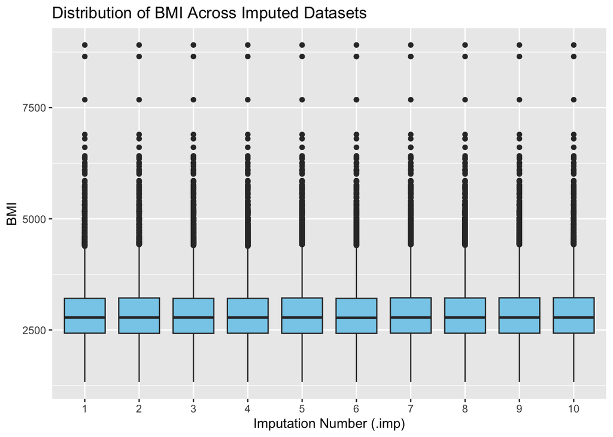

```r
ggplot(longimp, aes(x = as.factor(`.imp`), y = bmi)) +
  geom_boxplot(fill = "skyblue") +
  labs(
    x = "Imputation Number (.imp)",
    y = "BMI",
    title = "Distribution of BMI Across Imputed Datasets"
  )
```

## 10. Use stripplot to look at scatterplots of BMI by imputation. Do you see any notable patterns between imputations? Are the imputed data points within the range of the non-imputed data points?

[figure not shown]

```r
stripplot(x=imp, # mids obj)
          data=age + income +bmi +bmi_miss ~.imp,
          jit=TRUE,
          pch=c(1,20),
          xlab="Blue = non-missing, imputation numbers")
```

## 11. Run a linear regression using the non-imputed dataframe (i.e. a complete case analysis) modeling BMI as a function of income and two other predictors of your choice. Get a summary of the results.

```r
fit <- lm(bmi ~ age + income, data = df)
nobs(fit)         # number of complete cases
```

```
## [1] 7521
```

```r
fit
```

```
##
## Call:
## lm(formula = bmi ~ age + income, data = df)
##
## Coefficients:
##                  (Intercept)                           age
##                     2970.043                        -1.161
##   income$15,000 to < $25,000    income$25,000 to < $35,000
##                       50.948                        15.831
##   income$35,000 to < $50,000   income$50,000 to < $100,000
##                       35.773                        -1.961
## income$100,000 to < $200,000        income$200,000 or more
##                      -27.759                      -147.092
```

```r
summary(fit) # get model summary results
```

```
##
## Call:
## lm(formula = bmi ~ age + income, data = df)
##
## Residuals:
##     Min      1Q  Median      3Q     Max
## -1570.1  -459.9  -102.4   329.6  5750.2
##
## Coefficients:
##                               Estimate Std. Error t value Pr(>|t|)
## (Intercept)                  2970.0429    38.5387  77.067  < 2e-16 ***
## age                            -1.1609     0.4617  -2.514  0.01195 *
## income$15,000 to < $25,000     50.9484    37.6450   1.353  0.17597
## income$25,000 to < $35,000     15.8307    36.5112   0.434  0.66460
## income$35,000 to < $50,000     35.7726    35.8183   0.999  0.31796
## income$50,000 to < $100,000    -1.9609    31.9782  -0.061  0.95111
## income$100,000 to < $200,000  -27.7592    33.6675  -0.825  0.40968
## income$200,000 or more       -147.0917    45.9550  -3.201  0.00138 **
## ---
## Signif. codes:  0 '***' 0.001 '**' 0.01 '*' 0.05 '.' 0.1 ' ' 1
##
## Residual standard error: 663.9 on 7513 degrees of freedom
##   (2479 observations deleted due to missingness)
## Multiple R-squared:  0.004211,   Adjusted R-squared:  0.003283
## F-statistic: 4.539 on 7 and 7513 DF,  p-value: 4.588e-05
```

Sample size: 7,521 complete cases (2,479 dropped due to missingness).

Model fit:

R² = 0.0042 (very small, <1% variance explained).

F-test significant (p < 0.0001), meaning the model overall is statistically significant, but not practically strong.

Age:

Each additional year of age is associated with a slight decrease in BMI (β = -1.16, p = 0.012).

Income:

Most income categories are not significantly different from the reference group.

Exception: those earning $200,000 or more had substantially lower BMI compared to the reference category (β = -147.1, p = 0.0014).

## 12. Now run a linear regression using the imputed data with the same variables as above. Pool the regression coefficents and standard errors and obtain a summary.

```r
fit_i <- with(imp, lm(bmi ~ age + income, data = df))
summary(fit_i)
```

```
## # A tibble: 80 × 7
##    term                   estimate std.error statistic p.value  nobs df.residual
##    <chr>                     <dbl>     <dbl>     <dbl>   <dbl> <int>       <dbl>
##  1 (Intercept)             2970.      38.5     77.1    0        7521        7513
##  2 age                       -1.16     0.462   -2.51   0.0119   7521        7513
##  3 income$15,000 to < $2…    50.9     37.6      1.35   0.176    7521        7513
##  4 income$25,000 to < $3…    15.8     36.5      0.434  0.665    7521        7513
##  5 income$35,000 to < $5…    35.8     35.8      0.999  0.318    7521        7513
##  6 income$50,000 to < $1…    -1.96    32.0     -0.0613 0.951    7521        7513
##  7 income$100,000 to < $…   -27.8     33.7     -0.825  0.410    7521        7513
##  8 income$200,000 or more  -147.      46.0     -3.20   0.00138  7521        7513
##  9 (Intercept)             2970.      38.5     77.1    0        7521        7513
## 10 age                       -1.16     0.462   -2.51   0.0119   7521        7513
## # ℹ 70 more rows
```

Intercept: 2970.0 (baseline BMI for reference income group, age = 0).

Age: -1.16 (SE = 0.46, p = 0.012) → each additional year of age is associated with a slight decrease in BMI.

Income:

Most income categories (15k–200k) → not significant (p > 0.05).

Highest income group ($200,000 or more) → significantly lower BMI (β = -147.1, p = 0.0014).

Age is negatively associated with BMI.

The highest income group has significantly lower BMI.

Other income categories are not significant.

```r
fit_i <- summary(pool(fit_i))
fit_i
```

```
##                           term    estimate  std.error   statistic       df
## 1                  (Intercept) 2970.042928 38.5386774 77.06655054 7510.187
## 2                          age   -1.160895  0.4617228 -2.51426770 7510.187
## 3   income$15,000 to < $25,000   50.948422 37.6449883  1.35339188 7510.187
## 4   income$25,000 to < $35,000   15.830746 36.5112264  0.43358571 7510.187
## 5   income$35,000 to < $50,000   35.772586 35.8183389  0.99872263 7510.187
## 6  income$50,000 to < $100,000   -1.960923 31.9781959 -0.06132062 7510.187
## 7 income$100,000 to < $200,000  -27.759176 33.6674994 -0.82450958 7510.187
## 8       income$200,000 or more -147.091729 45.9549935 -3.20077792 7510.187
##       p.value
## 1 0.000000000
## 2 0.011948719
## 3 0.175971202
## 4 0.664601765
## 5 0.317961250
## 6 0.951105501
## 7 0.409676259
## 8 0.001376277
```

## 13. Compare the income coefficients between the complete case analysis and the imputed data analysis qualitatively and comment on whether there are any meaningful differences

```r
complete_case <-lm(bmi ~ age + income, data = df)
# bmi = b0+b1(age)+b2(income)+e
summary(complete_case)
```

```
##
## Call:
## lm(formula = bmi ~ age + income, data = df)
##
## Residuals:
##     Min      1Q  Median      3Q     Max
## -1570.1  -459.9  -102.4   329.6  5750.2
##
## Coefficients:
##                               Estimate Std. Error t value Pr(>|t|)
## (Intercept)                  2970.0429    38.5387  77.067  < 2e-16 ***
## age                            -1.1609     0.4617  -2.514  0.01195 *
## income$15,000 to < $25,000     50.9484    37.6450   1.353  0.17597
## income$25,000 to < $35,000     15.8307    36.5112   0.434  0.66460
## income$35,000 to < $50,000     35.7726    35.8183   0.999  0.31796
## income$50,000 to < $100,000    -1.9609    31.9782  -0.061  0.95111
## income$100,000 to < $200,000  -27.7592    33.6675  -0.825  0.40968
## income$200,000 or more       -147.0917    45.9550  -3.201  0.00138 **
## ---
## Signif. codes:  0 '***' 0.001 '**' 0.01 '*' 0.05 '.' 0.1 ' ' 1
##
## Residual standard error: 663.9 on 7513 degrees of freedom
##   (2479 observations deleted due to missingness)
## Multiple R-squared:  0.004211,   Adjusted R-squared:  0.003283
## F-statistic: 4.539 on 7 and 7513 DF,  p-value: 4.588e-05
```